# Lab 2: Week 2

- Show All Code
- Hide All Code
- View Source

Author

Hruday

# 1 Exploring with PCA

It would be nice if we can visualise our data with a 2D scatter-plot. However, for each patient, there are more than 10000 variables. How are we going to visualise this information for each patient? Similar to Lab 1, we can use a dimension reduction technique called PCA. PCA helps to reduce or summarise the information of a high dimensional object into a lower dimension. We can then use the first and second dimension, as the summary information of the >10000 genes, to plot a 2D scatter-plot. The PCA plot frequently gives us a good indication of how simple or difficult the relevant prediction task is. Please submit this plot for formative feedback and comment (1 sentence only) on what you learn from looking at this graph. Take care to make sure the graphic is properly labelled.

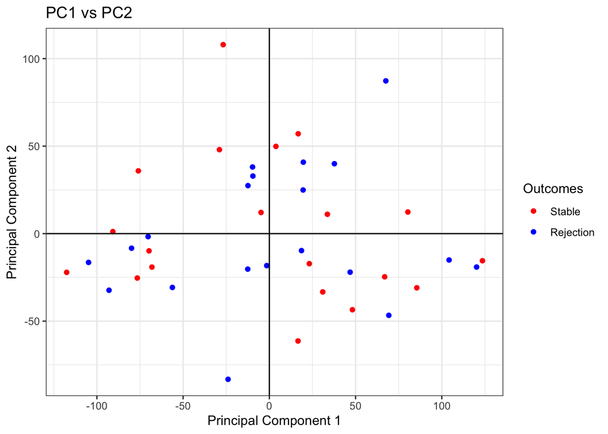

```r
eDF = t(data.frame(eMat))
pca.eDF = t(summary(prcomp(eDF))$x)
bind.pca.edf = rbind(eMat, pca.eDF)

outcomes = t(data.frame(c(gse$Outcome) == "Rejection"))
rownames(outcomes) = c('Outcomes')
colnames(outcomes) = colnames(bind.pca.edf)
bind.pca.edf = rbind(bind.pca.edf, outcomes)
bind.pca.edf = data.frame(t(bind.pca.edf))

bind.pca.edf |> ggplot() + geom_point(aes(x=PC1, y=PC2, color=factor(Outcomes))) + theme_bw() + xlab('Principal Component 1') + ylab('Principal Component 2') + scale_color_manual(name="Outcomes", values=c("red", "blue"), labels=c("Stable", "Rejection")) + geom_hline(yintercept=0) + geom_vline(xintercept=0) + ggtitle("PC1 vs PC2")
```